# NHP Royal Liverpool length of stay and single-occupancy room impacts

Author

Andy Hood, Jacqueline Grout and Zoe Turner

Published

2023-10-25

## Introduction

The New Hospitals Programme (NHP) team are considering the assumption that introducing single rooms will reduce average length of stay by 12%. This number that has been quoted has not been verified or tested.

Section 8 of the [Better, broader, safer using health data for research and analysis](https://www.gov.uk/government/publications/better-broader-safer-using-health-data-for-research-and-analysis/better-broader-safer-using-health-data-for-research-and-analysis) states:

> Ensure all code for data curation and analysis paid for by the state through academic funders and NHS procurement is shared openly, with appropriate technical documentation, to all data users. Data preparation, analysis and visualisation is complex technical work, requiring collaboration by many individuals, who may never meet, in a range of organisations, across the NHS and other sectors. The only way to manage this shared complexity is by sharing information, as in other technical fields.

The source of this assumption may come from the experience and analysis from recently opened hospital such as Royal Liverpool Hospital (opened October 2022) which had all single rooms, however, the analysis and code does not exist or is not available to review. The Strategy Unit therefore aims to provide some insight as the potential direction of effect on length of stay of single-occupancy rooms compared to multi-occupancy rooms or wards. The following is a brief exploratory analysis of length of stay patterns for admitted patients at Royal Liverpool hospital.

Through necessity, this analysis was conducted rapidly, is crude and carries significant caveats and limitations. However; it may be indicative that the theory has some credit and that more robust in-depth work is required to quantify the potential impact on whole hospital or sub-hospital populations that may be considered in future bed modelling.

### Evidential context

A systematic literature search and review was not undertaken as part of this work, however a rapid search on key terms (single occupancy and reduced length of stay) did highlight some recent empirical evidence of effects.

A BMJ systematic review (Bertuzzi et al. 2023) suggested a non-significant reduction of 10% in length of stay after change to single rooms. Another recent literature review (Kinloch J 2023) for NHS Scotland found single-occupancy rooms impact was variable (increased and decreased LoS depending on patient groups) and may be more effective for post-operative stays.

Qualitative work has pointed to factors and consequences on staff and patients (Maben J 2016) outside of the direct association on length of stay such as infection rates, isolation and staff workload/movement that should be considered.

## Analysis plan

In order to evaluate the hypothesis that single rooms might reduce the average length of stay we will undertake:

### Trend analysis / Statistical Process Control chart

If there are enough points then an SPC chart can be used to detect significant variance from prior or overall measures of length of stay, otherwise the analysis can be on a traditional run chart.

This will be done by week to provide standard units of time which calendar months cannot do: February is a short month so will always be lower in number.

### Benchmarking

Comparing the data with hospitals in England, near neighbour hospitals or regional sites could show that there may be another effect extant to single rooms that is impacting length of stay.

Published evidence on single occupancy (perhaps from other countries) should be referred to alongside this analysis.

### Case mix

If the hospital beds have changed or a new hospital has replaced an old, the types of procedures that are carried out needs to be compared to ensure that the change is not related to changes in medical care. Different procedures may have different lengths of stay, and types of patients that present may also affect it (those with more complex needs).

Initially we will use treatment specialty on admission as a proxy for case-mix. More work could be done to specify this.

## Trend analysis

Initially, we will look at the underlying trend in length of stay by week of admission compared to other hospitals across the rest of the country and up to the point that the single-occupancy room site was adopted (Oct 2022). The comparator group of hospitals is all those who submit data to SUS and who have a type 1 ED department. Is Liverpool typical of acute trusts? Was their length of stay higher or lower than benchmarks at the point the new site began operation?

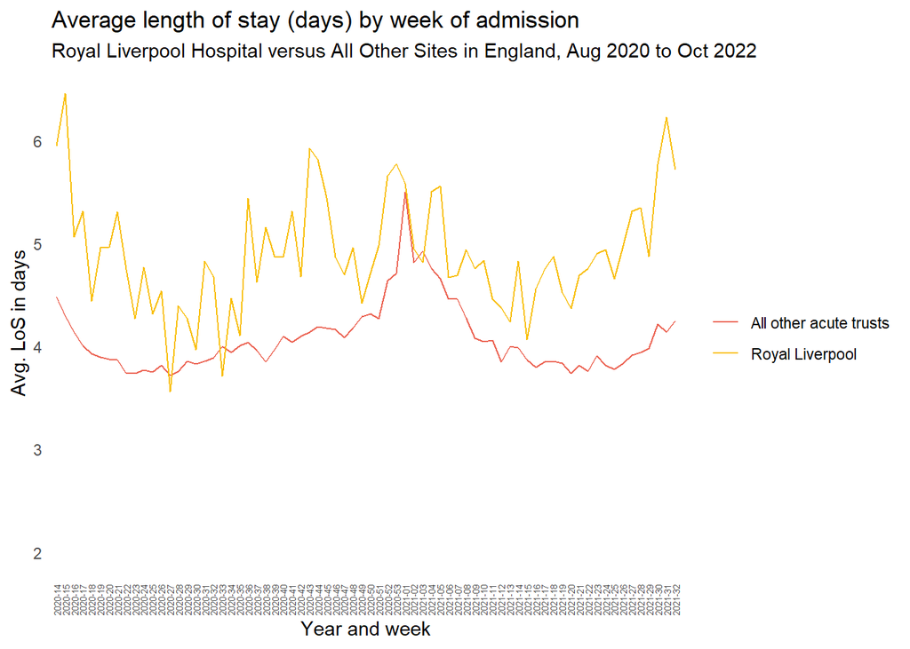

**Length of stay longer at Royal Liverpool Hospital**

In order to observe the potential change in length of stay patterns in multi-bed wards and rooms in the old hospital compared to single-bed rooms in the new hospital, we plot the length of stay averages by week of all the patients admitted to Royal Liverpool (REMRQ) between August 2021 (end of legal covid restrictions) and August 2023.

The week of transition between the old and new hospital (officially the 20th October 2022) is indicated by a vertical blue line on the plots and red dashed lines (pre new site) and green dashed lines (post move to new site) show the linear trends of those periods.

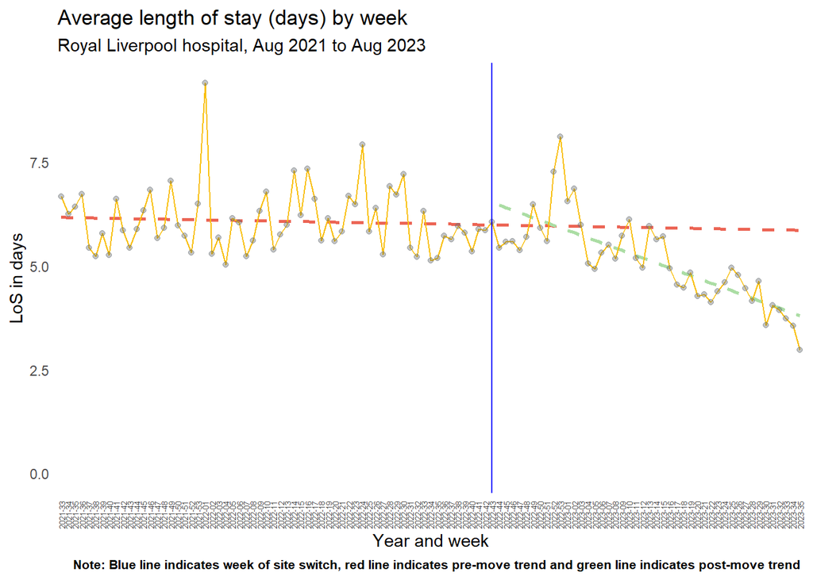

The change in length of stay patterns from the old hospital to the new hospital shows a difference between elective and non-elective spells as can be seen below. Average length of stay has seen a step change increase in elective spells, but with a declining trend following the hospital move. In contrast the non-elective spell average length of stay has decreased following the move.

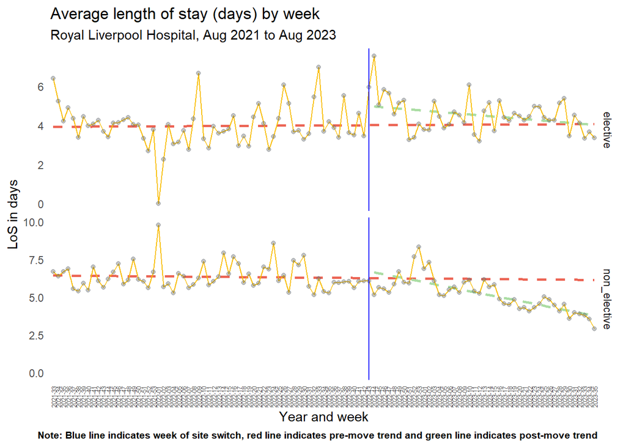

## Benchmark analysis

One limitation of considering only the activity at the Royal Liverpool hospital over the specified time period is that the effects might be similar elsewhere and therefore the single/multiple bedded rooms might not be a variable of influence.

To test this, we have extracted and present the same set of activity for the 5 nearest other hospitals providing general acute services to (among others) patients from Liverpool:

- Aintree
- Whiston
- Southport and Formby
- Ormskirk and district
- Countess of Chester

**Aintree**

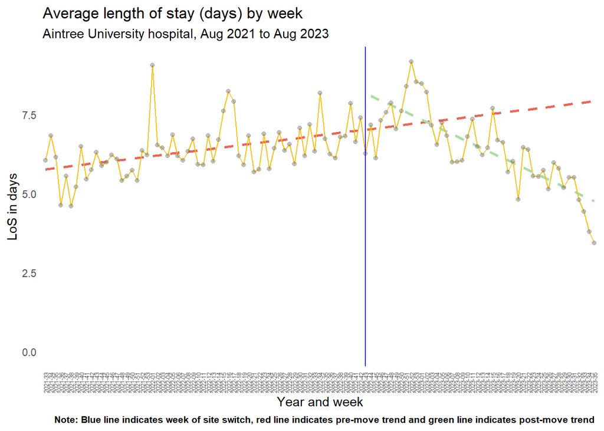

**Whiston**

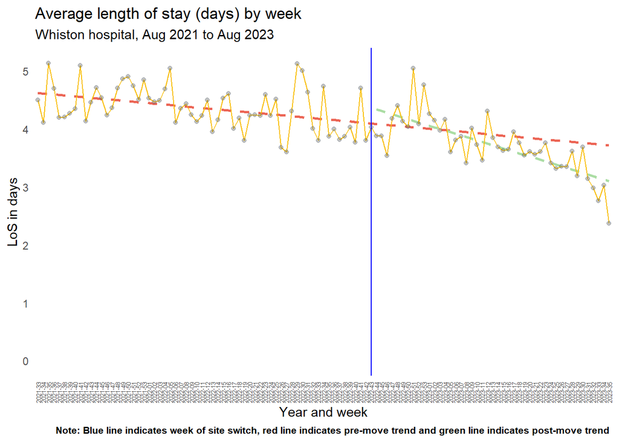

**Southport & Formby**

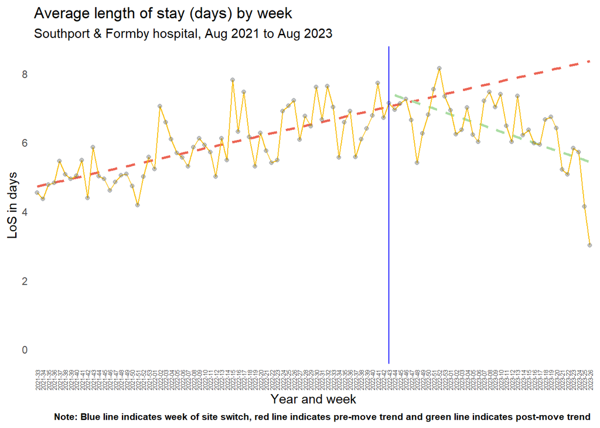

**Ormskirk & District**

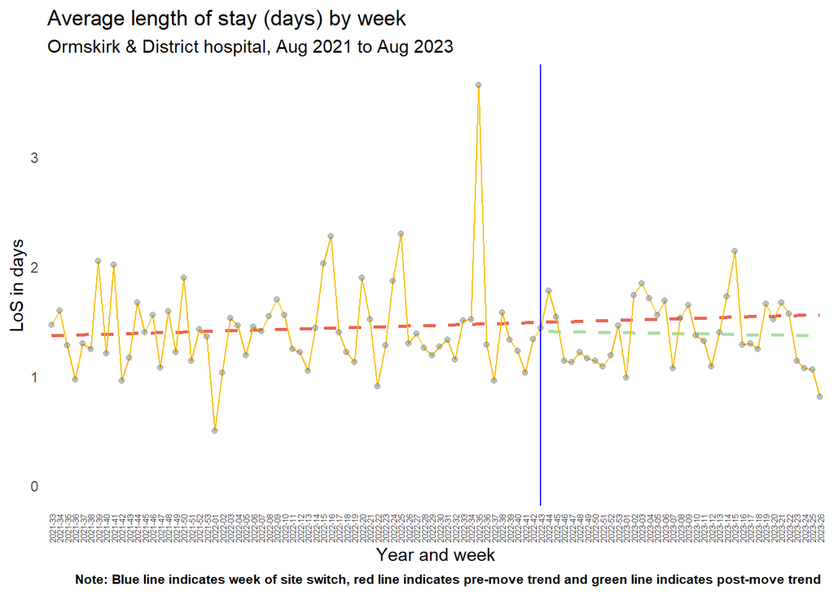

**Countess Chester**

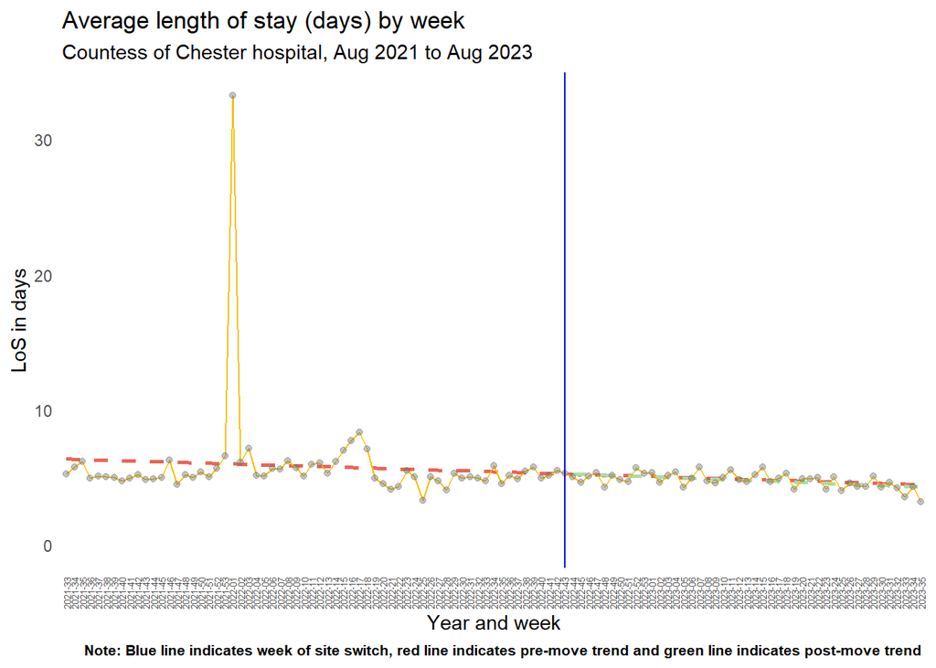

**Control hospital observations**

Aintree University Hospital, also operated by Royal Liverpool NHS Trust, demonstrates a similar pattern in average length of stay to Royal Liverpool despite not having moved to single-occupancy facilities. This suggests there may be other systematic changes that have occurred trust-wide.

LoS trends at Whiston, Southport & Formby and Ormskirk Hospitals also appear to have varying reduced length of stay since October 2022. Countess of Chester shows a continuing trend of a declining average length of stay over the period August 2021 to August 2023.

## Case-mix

Another potential cause of changes in length of stay may be the case mix of patients admitted to both the old and new hospitals - have services or admission thresholds or surgical case-loads changed?. In this data, we have used the treatment specialty on admission as a proxy for case-mix and repeated the trend analysis to indicate if length of stay changes might be driven by clinical groupings. We have identified the top 5 treatment specialties in elective and non-elective (excluding 180) by spell volume for the period after the hospital move. These are presented below:

### Elective

**Urology**

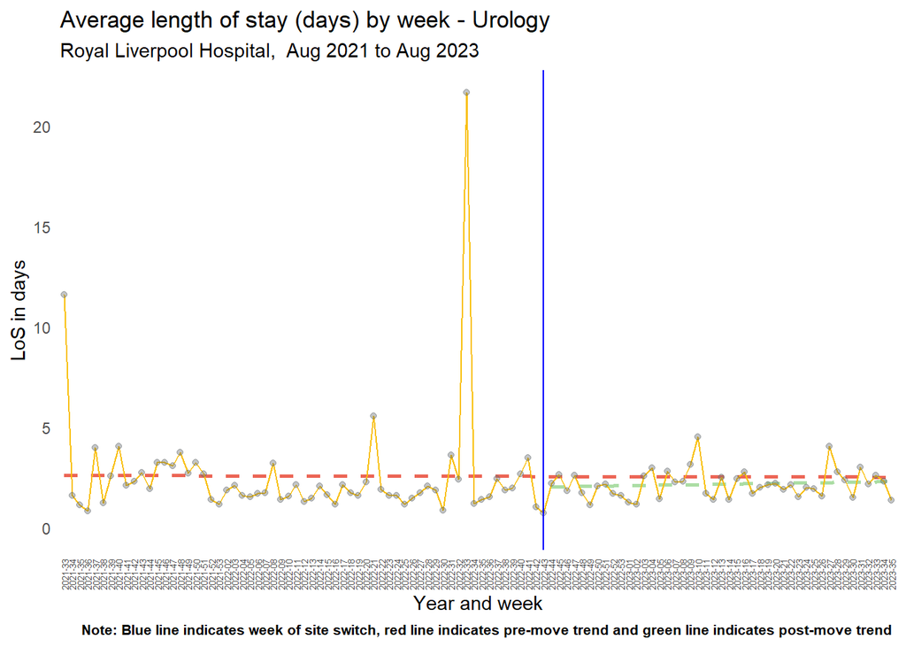

**Hepatobiliary & Pancreatic Surgery**

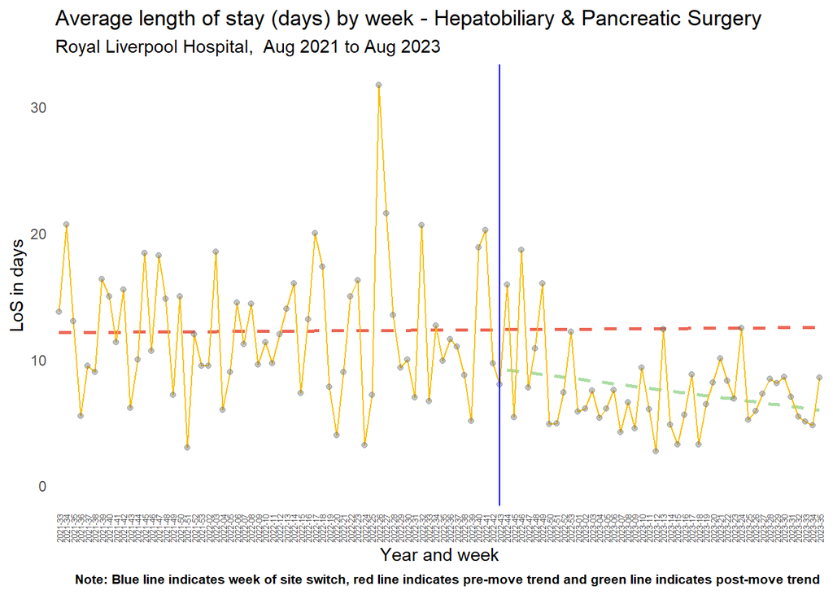

**Colorectal Surgery**

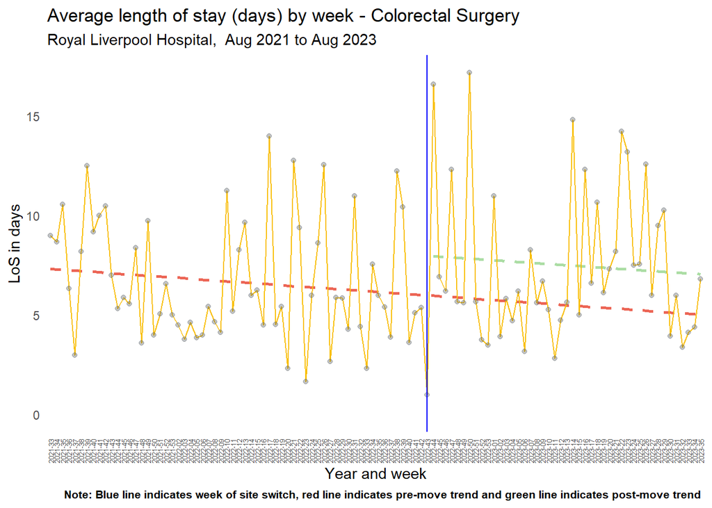

**Opthalmology**

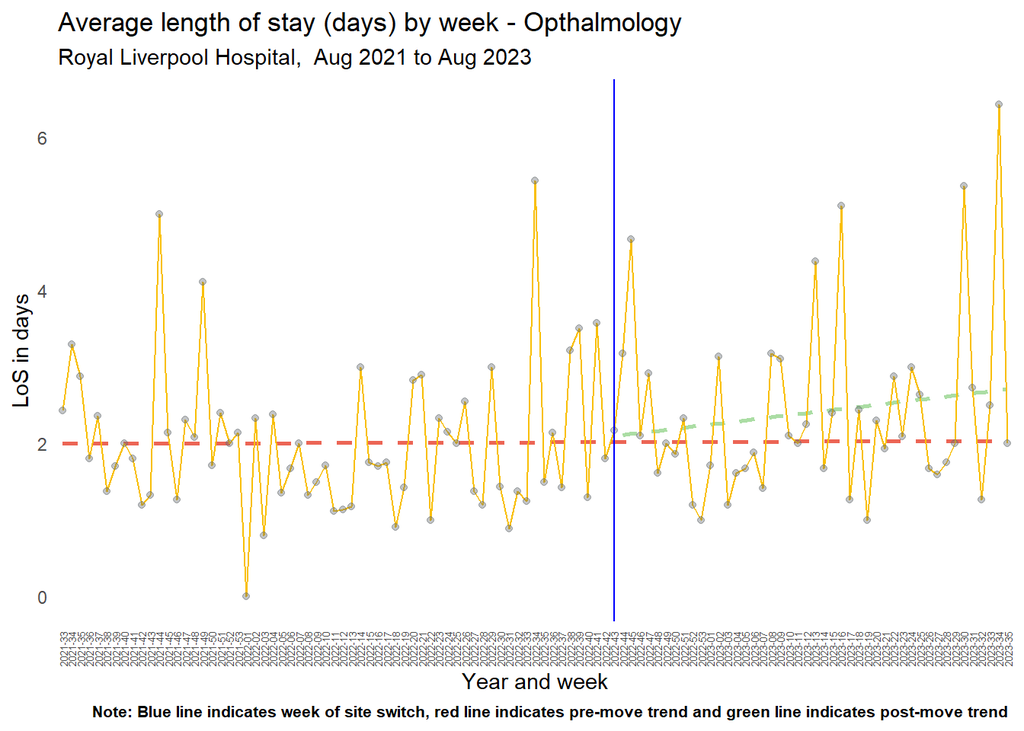

**Transplantation Surgery**

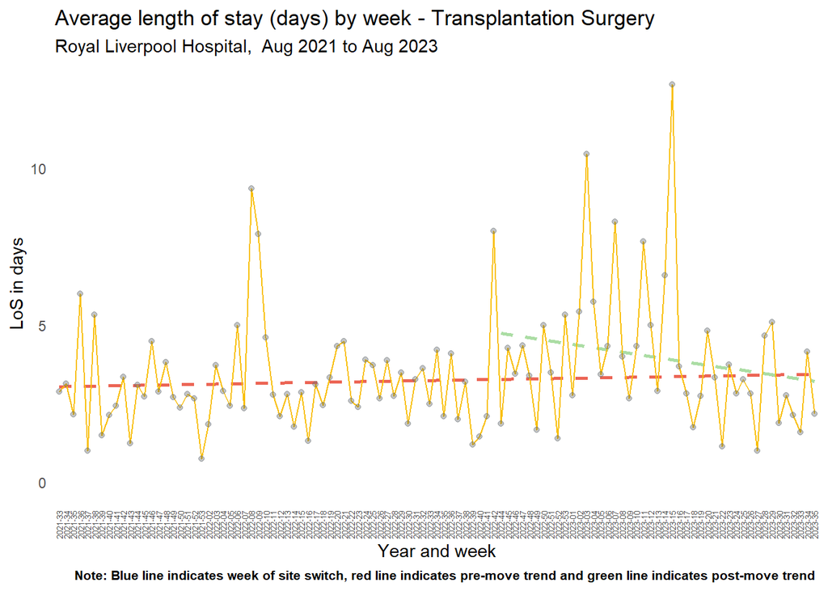

**Elective case-mix variation**

Whilst the change in average length of stay for elective shows a slight trend of a reducing length of stay following a stepped change increase after the move to the new hospital site, variation can be seen between specialties.

Hepatobiliary and Pancreatic Surgery has seen a step change of a reduced average length of stay with further reductions sustained over the 10 months since the hospital move.

Transplantation Surgery shows a declining trend in average length of stay following the hospital move. However, this follows a marked step change increase in the average length of stay following the move to the new site.

### Non-Elective

**General Medicine**

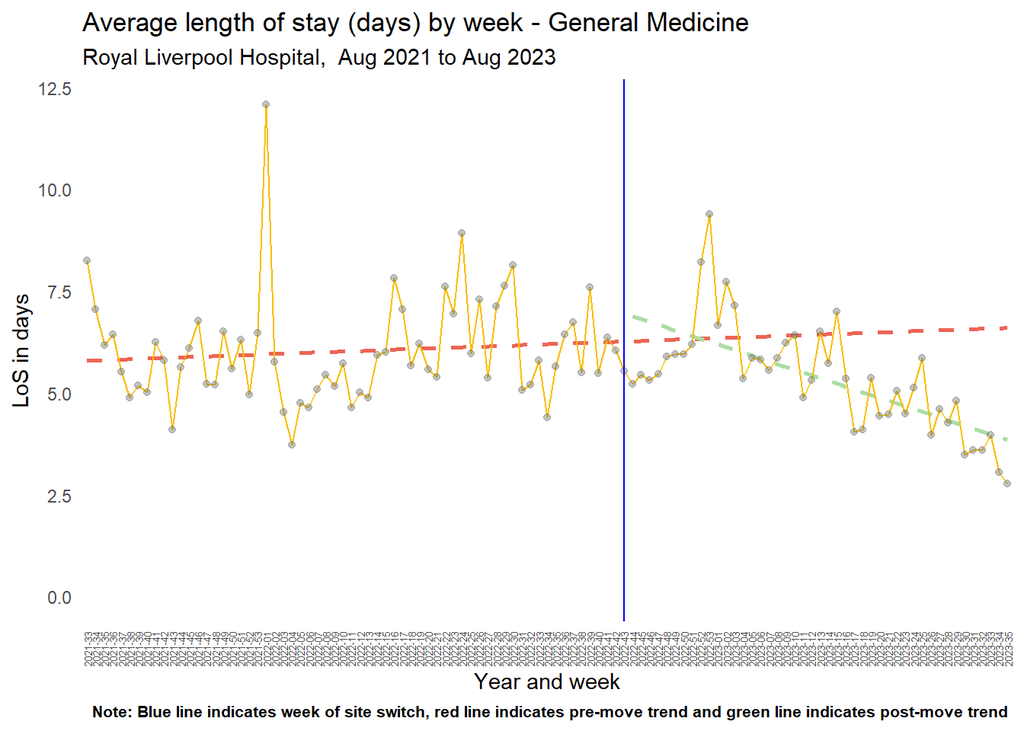

**General Surgery**

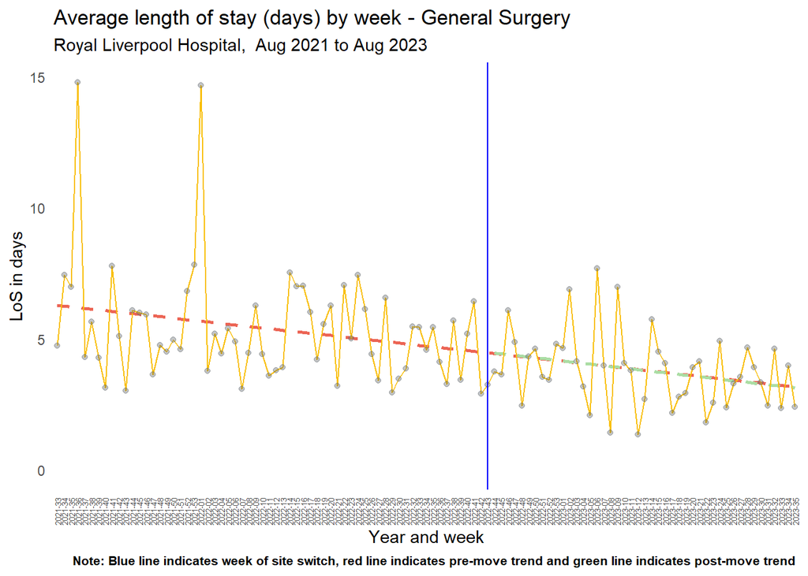

**Cardiology**

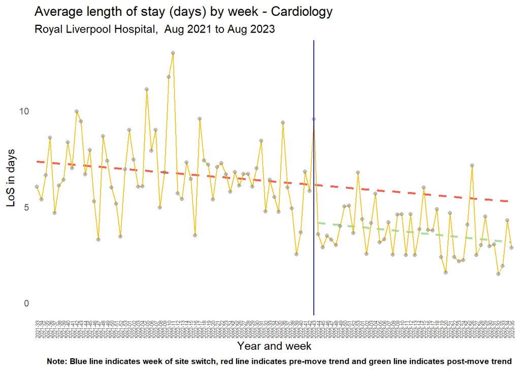

**Urology**

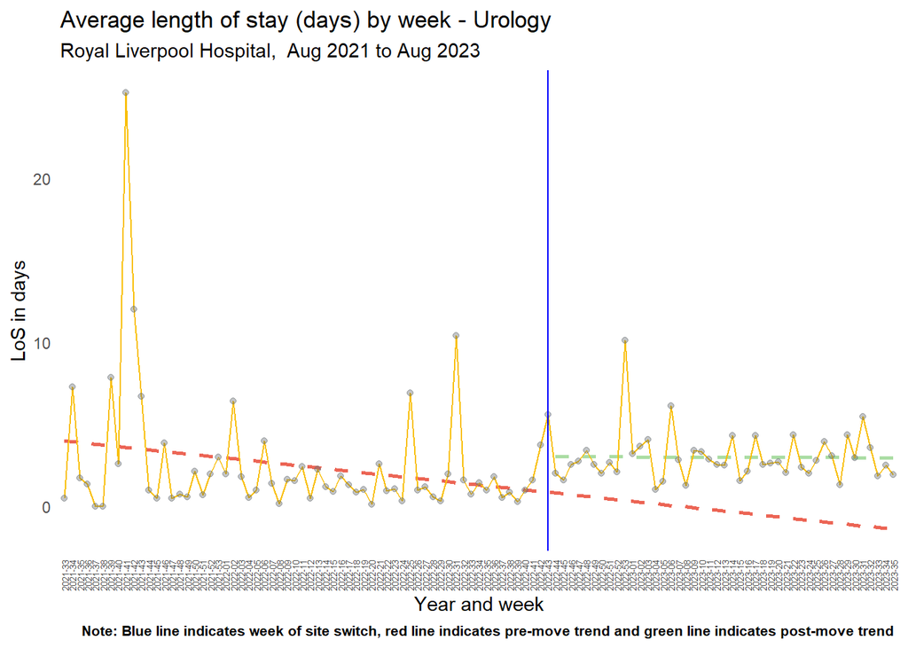

**Elderly Medicine**

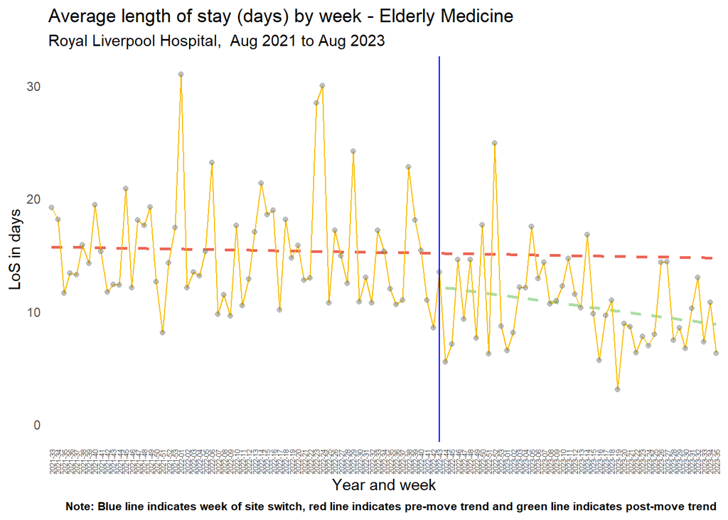

**Non-elective case-mix variation**

Prior to the move non-elective Cardiology had a trend of a declining average length of stay and following the move has seen a step change to a further reduced average length of stay, with a sustained continuation of this decline.

There has been a continuation of the already present declining trend in non-elective General Surgery average length of stay following the move to the new hospital site.

There is a contrasting picture for non-elective Urology where prior to the move to the new hospital there was a declining trend in average length of stay. Following the site move the data shows a marked increase in average length of stay and this average length of stay has remained fairly stable since the move. Further investigation would be needed to identify whether there has possibly been other changes within the specialty or the wider-system to lead to such a change.

## Summary, discussion and next steps

There are indications that single-occupancy rooms may have reduced length of stay for patients at Liverpool Royal Hospital slightly more than changes seen at neighbouring trust sites. However; length of stay averages at the Trusts other large site in Liverpool (Aintree) have followed a similar pattern over the same time period suggesting perhaps trust-wide systemic changes to discharge practice and/or pathways.

The reductions in length of stay have also not persisted for all sub-groups:

- Elective admissions have been impacted much less
- General Medicine, Cardiology and Elderly Medicine have seen large decreases since October 2022
- Urology patients are now staying substantially longer

As such, in our view and based on this initial exploration, any universal assumptions about length of stay reductions as a result of single occupancy rooms (in the region of 12%) are likely to be overstated (given changes at non-single-occupancy room sites) and would also ignore differential effects on different patient groups.

This analysis has been performed on only one metric - average length of stay - and only in the dimension of time - pre and post ‘event’. However; a change in the building or processes within a building can result in a change in working and/or caseloads.

- The type of patients treated by the provider, by the patient’s condition or by the catchment area.
- Staffing models and ratios may have changed with factors such as catchment area, change in working practice, loss or gaining of staff.

Additionally, access to only SUS data is a limiting factor in being able to fully understand the broader impact on patients, their support network and also staff.

### Data caveat

Admitted patients yet to be discharged will not be represented in the SUS data we have utilised for this analysis. The data we have used covers admissions up to 31st August 2023 and discharges up to 30th September 2023. As such, some patients with a length of stay > 30 days will not be represented in more recent average LoS thus bringing those figures down artificially. We believe this is only a very marginal affect, but recommend the analysis is re-run as SUS data is refreshed to represent the most topical view of trends. Omitting the most recent admission month from the series may be an alternative ‘fix’.

### Next steps

After our initial investigations more detailed analysis should be considered in order to make more informed conclusions about the impacts addressed including:

- thorough review of published evidence
- interrupted time series (incorporating ARIMA)
- retrospective matched cohort analysis
- standardisation of length of stay for age/sex/comorbidities etc…
- quantifiaction of other indirect effects (positive and negative) such as healthcare-acquired infection rates, staff productivity, patient experience.

## References

Bertuzzi, Andrea, Alison Martin, Nicola Clarke, Cassandra Springate, Rachel Ashton, Wayne Smith, Andi Orlowski, and Duncan McPherson. 2023. ‘Clinical, Humanistic and Economic Outcomes, Including Experiencing of Patient Safety Events, Associated with Admitting Patients to Single Rooms Compared with Shared Accommodation for Acute Hospital Admissions: A Systematic Review and Narrative Synthesis’. *BMJ Open* 13 (5). https://doi.org/10.1136/bmjopen-2022-068932.

Kinloch J, Rodriguez-Labajos L. 2023. ‘Impact of Room Design on Length of Stay: Systematic Literature Review’. NHS Scotland. https://www.nss.nhs.scot/media/4115/literature-review-impact-of-room-design-on-length-of-stay-v1.pdf.